# Stereotypes in Western Media

Heran Mengisteab, Anchal Kohli, Carter Raaen, Caden Henson

2/18/2022

## Affiliation:

INFO-201: Technical Foundations of Informatics - The Information School - University of Washington

##Date: Winter 2022

## Abstract:

Racial stereotypes have existed long before the film industry due to colonialism. Many depictions of non-white characters on film were root in racial biases and cultural ignorance.Cinematic stereotypes reflect and shape common prejudices. Perceptions can be influenced by portrayals of Asians as nerdy, black men as dangerous and Latinas as fiery.

## Keywords:

_Stereotypes, Cinema, Racism, Sexism, and Society__

## 1.0 Introduction:

Stereotypes regarding race and gender are a big issue in western media. Not only does this affect the youth and their growing perspectives on people in society, it also encourages adults to continue to stereotype. Due to the spread of misinformation through the media, there have been multiple incidences where these stereotypes have been used against many individuals. There are multiple examples of shows targeting the youth which have many stereotypes. One example of this is the show Jessie on Disney Channel. The show includes four kids who are adopted and live with a nanny. There is an Indian boy, an African American girl, a white boy, and a blonde girl. The Indian boy is shown as weak and nerdy with an Indian accent. The African American girl is shown as rebellious and sassy. The white boy is shown as athletic and the blonde girl is shown as dumb and boy obsessed.

## 2.0 Design Situation:

**Framing the topic of concern. What is the topic of concern, problem domain or design situation?** The topic of concern which we hope to gain more knowledge, and data for is the stereotyping of gender and race through western media.

**What are the key elements of the topic?** The key elements of stereotypes found in Television, Movies, and Advertisements are racism, discrimination, bias, and bullying.

**What are the key scientific, cultural, social, governmental, or economic issues or questions?** The key social issues and impacts of stereotyping is that many individuals may be discriminated against due to another individuals false perception of them. Through watching media at a young age, many individuals may imprint an idea or an impression of a group of people due to the way they are shown in cinema. Implicit bias can also occur due to the imprinted idea of certain groups with a common identity. Unknowingly, seeing similar characters with similar characteristics in media over and over again can cause an audience to view those individuals and categorize all of them in that way.

**Human values** The human values that are connected to the western media’s perception of gender and people of color, are inclusion and respect. These values originate with the idea of appealing to a greater audience, and allowing more individuals to connect with positive perceptions of people of their same identity groups. Media is supposed to inspire all individuals, especially western media which appeals to a diverse audience.

**Stakeholders** Direct Stakeholders regarding stereotypes and creating characters in western media are writers, character artists, directors and producers. These individuals are motivated by creating a project for a greater audience which will allow all people to be able to relate and feel inspired by the characters. The indirect stakeholders are the audience watching the media. They are indirect stakeholders because they are affected by the change through a switch in perspective of individuals as well as those minority groups who are usually stereotypes in media will start to face less bias and discrimination.

**Benefits and Harms** There could be a lot of benefits and harms with interventions taken to get rid of stereotypes in Hollywood. Bringing in more diversity into the film industry to get more individuals to look over character creations and story productions will allow for a decline in privilege hazard, bias, and racism when creating characters for a greater audience. Some harms of this could be many individuals disagreeing with what is racist and what is not or what is okay to put and what is not because there is not really a right or wrong answer. Some unanticipated consequences could be that some individuals could feel that the diversity is too forced and the media has become to progressive too fast. Some individuals may also feel like due to sudden change they don’t enjoy the media as much because of how careful, sensitive and unrelatable.

## 3.0 Research:

**How do stereotyped characters in media affect students?**

**Has bullying or discrimination increased due to the steryotypes in media?**

**Does the rate of hate crimes correlate with the media’s stereotypes?**

Stereotypes are generalizations that are assigned to groups of people. These groupings can be by race, class, gender, religion, country of origin, etc. The generalizations (whether negative or positive) are used to confine a group to others’ standards and expectations. Our media and film contribute heavily to the perpetuation of stereotypes. By showcasing generalizations and presenting them as common concepts, they become mainstream ideas. We haven’t completely gotten away from these stereotypes in movies but there are strides being made. These questions are to show that the stereotypes seen on tv and film can manifest in real life. This is because people will internalized what they’ve seen or don’t see in their lives. People can be mistrusted and mistreated because of the stereotype associated with their group; racial profiling young black men is a contentious issue in the United States, while people perceived as Muslim, some of whom were in fact adherents to other faiths, were treated degradingly following the September 11th terrorist attacks. We are able to combat this by adding more inclusion and diversity. They have found that prejudices breaks down when people of various ethnic groups have increased contact with each other. A sociologist by the name of Nancy Wang Yuen said that “Racism, in the form of job exclusion and racially stereotyped roles, has defined the Hollywood film industry since its birth in the early 1900s” *(Reel Inequality: Hollywood Actors and Racism)*.

## 4.0 The Dataset See Design:**

When deciding what movie to watch, how important are the following? The movie avoids racial stereotypes. This data comes from an online survey which received 2,201 responses, all of which were of at least 18 years of age. This survey asked: *“When deciding what movie to watch, how important are the following? The movie avoids racial stereotypes.”* Thus, one observation equates to one person’s response to this question. Respondents picked between five options: “very important,” “somewhat important,” “not that important,” “not important at all,” and “don’t know/no opinion.” These responses are grouped based on the participant’s race, ethnicity, religious beliefs, employment status, age, political standing, and more. In other words, many people from vastly different backgrounds are represented in this dataset.

This data was collected by The Hollywood Reporter and Morning Consult, and published by The Morning Consult, in May 2019. While not explicitly stated, the purpose of the study as a whole seems to be to gauge how people of different religious, political, and employment backgrounds consume media and partake in various lifestyles. Considering the involvement of The Hollywood Reporter, the data collection effect was likely funded by that publication so that they could better share the study’s findings as a part of their news offerings, and make more accurate conclusions about the state of the industries in question. Therefore, The Hollywood Report is likely to benefit from the data, as it improves their ability to make justifiable claims about various entertainment industries. Moreover, this dataset may give THR more ideas for news to publish, meaning that they will likely make money from the data. Unfortunately, it is hard to confirm whether the data is completely reliable and trustworthy, as the online survey format allows people to easily provide false information for the data collectors. More specifically, the source I linked states: “Results from the full survey have a margin of error of plus or minus 2 percentage points.” However, the sample size appears is large enough that individual errors are not likely to change anyone’s analysis of the data, nor is it likely to lead our group to reach false conclusions in the making of this project. I obtained this data through the website statista, which linked to the far more extensive pdf we will use for our project. I found the aforementioned statista page by searching for information on racial stereotypes in google’s dataset search webstie.

## 5.0 Expected Implications:

Some of the expected or possible implications that technologists, designers, and policymakers would need to have are general understandings based around what stereotypes are and how they are harmful. These for example can include how the media influences and impacts stereotypes and of how they can play a role in societal interaction. By having knowledge on these expected implications, these people will be able to perform their specific jobs more fairly and effectively in order to prevent groups of people from being mistreated. For example, if policy makers were to make and set policies into place that marginalized a certain group based on a misunderstanding of a certain group as a result of stereotypes, it would cause a lot of people within that group to potentially suffer and face harsh and unfair repercussions. By having this implied knowledge, this can be avoided and done properly.

## 6.0 Limitations:

Some of the limitations that might need to be addressed are the instances in which for example stereotypes are used in media, film, television, etc and not explicitly documented as it would make it hard to truly find and analyze accurate data surrounding the topic. There also isn’t directly a means of which we can access numbers or data on the subject because there is not really like an official database and it’s more so just information scattered online from various different sources and authors. With that however also comes the limitation of misinformation or information that is also not entirely accurate or credible which can make finding data even more difficult. Another limitation that might need to be addressed is the collection of the information by different users or sources as they may be biased or have pre-existing thoughts or beliefs about certain stereotypes and groups of people which can skew the data and alter it.

### Aggregate Table

```
## # A tibble: 9 x 2
## # Groups:   very_important [9]
##   ï..demographic      very_important
##   <chr>               <chr>
## 1 Age: 18-29          " 20% (99)"
## 2 Age: 30-44          " 23% (118)"
## 3 Age: 45-54          " 15% (56)"
## 4 Age: 55-64          " 13% (52)"
## 5 Age: 65+            " 11% (47)"
## 6 Ethnicity: Afr. Am. " 14% (37)"
## 7 Ethnicity: Hispanic " 11% (38)"
## 8 Ethnicity: Other    " 9% (19)"
## 9 Ethnicity: White    " 18% (315)"
```

### Chart 2

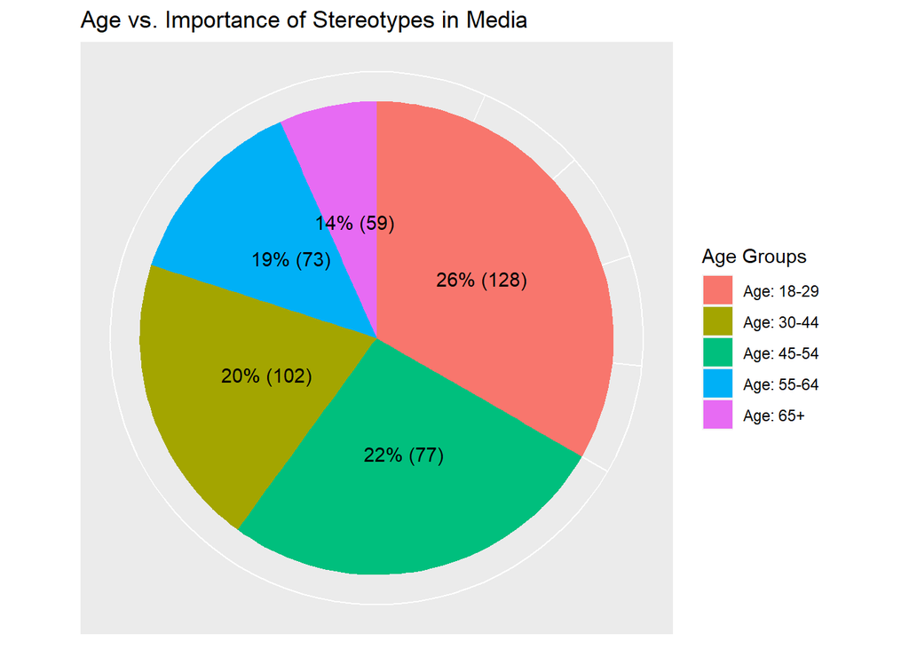

### Chart 3

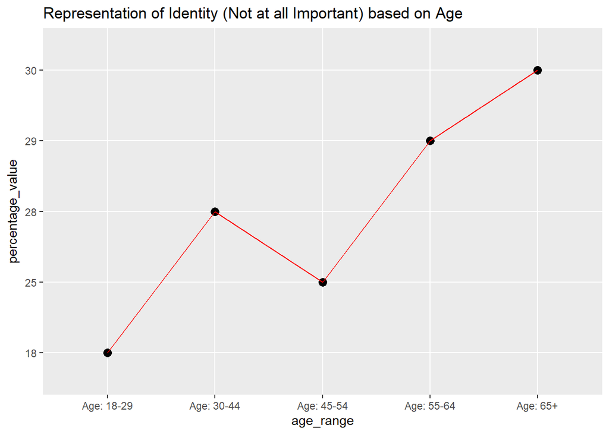

The purpose of this chart is show the difference in the level of importance people have about their identity being accurately portrayed in media and film based on age groups. Each dot on the graph shows the percentage of people in that age group who specifically didn’t find it important at all whether or not their identity was correctly portrayed or not. The line connecting the dots also shows the general change in level between the groups which can allow us to find correlations and trends within the data. One conclusion that we can see and make from the data itself is that as people get into their older years after around the age of 50, there is a less overall sense of care and importance of ones identity portrayal. In contrast however, we also from the graph can say the opposite in that younger people care far more as the first age group has the lowest percentage value out of all the groups on the graph.

## Resources: MLA Format

*Yuen, Nancy Wang. “How Racial Stereotypes in Popular Media Affect People - and What Hollywood Can Do to Become More Inclusive.” Scholars Strategy Network, 4 June 2019, https://scholars.org/contribution/how-racial-stereotypes-popular-media-affect-people-and-what-hollywood-can-do-become._ *Nittle, Nadra Kareem. “Persistent Racial Stereotypes in TV Shows and Movies.” ThoughtCo, ThoughtCo, 13 Dec. 2020, https://www.thoughtco.com/common-racial-stereotypes-in-movies-television-2834718.** “How Stereotypes in Movies and on TV Impact Kids’ Development [Downloadable].” CHC Resource Library, https://www.chconline.org/resourcelibrary/stereotypes-movies-tv-impact-kids-development-downloadable/._ *“Exploring Stereotypes with American Film and Television.” TeachMideast, https://teachmideast.org/lesson_plans/exploring-stereotypes-with-american-film-and-television/._* “Films/Videos for Teaching School of Communication Topics: Stereotyping and Cultural Representation in the Media and Popular Culture.” American University, https://subjectguides.library.american.edu/c.php?g=175267&p=2788310._ *Leonard, Kim. “Stereotypes in Movies and How Filmmakers Can Avoid Them.” StudioBinder, 5 Dec. 2019, https://www.studiobinder.com/blog/stereotypes-in-movies/.* *Schacht, Kira. “What Hollywood Movies Do to Perpetuate Racial Stereotypes.” DW.COM, 21 Feb. 2019, https://www.dw.com/en/hollywood-movies-stereotypes-prejudice-data-analysis/a-47561660._ *Gonchar, Michael. “26 Mini-Films for Exploring Race, Bias and Identity With Students.” The New York Times, 15 Mar. 2017, https://www.nytimes.com/2017/03/15/learning/lesson-plans/25-mini-films-for-exploring-race-bias-and-identity-with-students.html.* *Somvichian-Clausen, Austa. “Top 10 Films That Break Gender and Racial Stereotypes.” The Hill, 9 Dec. 2019, https://thehill.com/changing-america/respect/diversity-inclusion/473687-top-10-films-that-break-gender-and-racial._* “National Tracking Poll #190524.” https://morningconsult.com/wp-content/uploads/2019/05/190524_crosstabs_HOLLYWOOD_Adults_v1.pdf. Accessed 4 Feb. 2022. Morning Consult, May 2019.*